# Final project for DS 2.1 - Machine Learning - Andrey Novichkov

## Dataset - Student Alcahol Consumption (Kaggle)

**Questions I want to Answer:**

- What are the trends amongs male vs female students
- What are the overall correlations between the different features?
- See if Alcahol consumption affects final grades!
- What is the one feature that is the best predictor for the final grade(random forest)
- Build linear regression model that predicts grades
- Build classification models that predict pass/fail of a student
- PCA to try improve models

## 395 samples

## 33 features:

> 'school', 'sex', 'age', 'address', 'famsize', 'Pstatus', 'Medu', 'Fedu', 'Mjob', 'Fjob', 'reason', 'guardian', 'traveltime', 'studytime', 'failures', 'schoolsup', 'famsup', 'paid', 'activities', 'nursery', 'higher', 'internet', 'romantic', 'famrel', 'freetime', 'goout', 'Dalc', 'Walc', 'health', 'absences', 'G1', 'G2', 'G3'

## Let's get some general stats and explore the data

**Decided to look at these features:**

> 'sex', 'age', 'studytime', 'failures', 'goout', 'Dalc', 'Walc', 'absences', 'G3'

```python
alt.Chart(avg_feature_df).mark_bar().encode(
    x='sex:O',
    y='average:Q',
    color='sex:O',
    column='feature:O'
)
```

[interactive chart not shown]

```python
chart
```

[interactive chart not shown]

```python
alt.Chart(grade_df).mark_circle(size=60).encode(
    x='G3',
    y='G2',
    color='G1'
)
```

[interactive chart not shown]

## Do we have correlation among features?

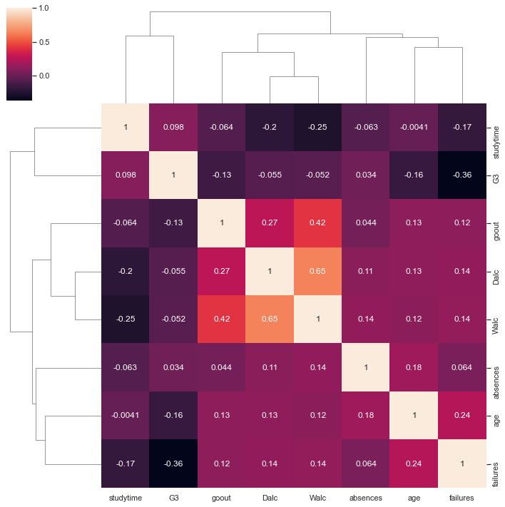

```python
_= sns.clustermap(data=sml_feature_df.corr(), annot=True)
```

## Let's see if we can build a good Linear Regression model on the small feature dataset

```python
sml_feature_df[:5]
```

|  | sex | age | studytime | failures | goout | Dalc | Walc | absences | G3 |
| --- | --- | --- | --- | --- | --- | --- | --- | --- | --- |
| 0 | F | 18 | 2 | 0 | 4 | 1 | 1 | 6 | 6 |
| 1 | F | 17 | 2 | 0 | 3 | 1 | 1 | 4 | 6 |
| 2 | F | 15 | 2 | 3 | 2 | 2 | 3 | 10 | 10 |
| 3 | F | 15 | 3 | 0 | 2 | 1 | 1 | 2 | 15 |
| 4 | F | 16 | 2 | 0 | 2 | 1 | 2 | 4 | 10 |

```python
from sklearn.linear_model import LinearRegression
from sklearn.metrics import mean_squared_error, r2_score
from sklearn.model_selection import train_test_split

X_train, X_test, y_train, y_test = train_test_split(X,y, test_size=.25, random_state=0)

lin_reg = LinearRegression()
lin_reg.fit(X_train, y_train)
y_pred = lin_reg.predict(X_test)
print(f'MSE error: {mean_squared_error(y_test, y_pred)}')
print(f'r^2 score: {r2_score(y_test, y_pred)}')
```

```
MSE error: 24.597125856592157
r^2 score: 0.13109328407319654
```

## That is a pretty bad model! LOL

### Let's see if normalizing the data will help!

```python
from sklearn.preprocessing import normalize

X_norm = normalize(X)

X_train, X_test, y_train, y_test = train_test_split(X_norm,y, test_size=.25, random_state=0)

lin_reg = LinearRegression()
lin_reg.fit(X_train, y_train)
y_pred = lin_reg.predict(X_test)
print(f'MSE error: {mean_squared_error(y_test, y_pred)}')
print(f'r^2 score: {r2_score(y_test, y_pred)}')
```

```
MSE error: 23.431019388434272
r^2 score: 0.17228662298504827
```

## Ok well, it improved a little bit, but not by that much!

Let's see if giving it more features will help! Let's also encode the non-numerical features!

```python
big_feature_df = df[feature_cols_big]
big_feature_df[:5]
```

|  | sex | age | studytime | failures | goout | Dalc | Walc | absences | romantic | famrel | health | G1 | G2 | G3 |
| --- | --- | --- | --- | --- | --- | --- | --- | --- | --- | --- | --- | --- | --- | --- |
| 0 | F | 18 | 2 | 0 | 4 | 1 | 1 | 6 | no | 4 | 3 | 5 | 6 | 6 |
| 1 | F | 17 | 2 | 0 | 3 | 1 | 1 | 4 | no | 5 | 3 | 5 | 5 | 6 |
| 2 | F | 15 | 2 | 3 | 2 | 2 | 3 | 10 | no | 4 | 3 | 7 | 8 | 10 |
| 3 | F | 15 | 3 | 0 | 2 | 1 | 1 | 2 | yes | 3 | 5 | 15 | 14 | 15 |
| 4 | F | 16 | 2 | 0 | 2 | 1 | 2 | 4 | no | 4 | 5 | 6 | 10 | 10 |

```python
big_feature_df = pd.get_dummies(big_feature_df)
big_feature_df[:5]
```

|  | age | studytime | failures | goout | Dalc | Walc | absences | famrel | health | G1 | G2 | G3 | sex_F | sex_M | romantic_no | romantic_yes |
| --- | --- | --- | --- | --- | --- | --- | --- | --- | --- | --- | --- | --- | --- | --- | --- | --- |
| 0 | 18 | 2 | 0 | 4 | 1 | 1 | 6 | 4 | 3 | 5 | 6 | 6 | 1 | 0 | 1 | 0 |
| 1 | 17 | 2 | 0 | 3 | 1 | 1 | 4 | 5 | 3 | 5 | 5 | 6 | 1 | 0 | 1 | 0 |
| 2 | 15 | 2 | 3 | 2 | 2 | 3 | 10 | 4 | 3 | 7 | 8 | 10 | 1 | 0 | 1 | 0 |
| 3 | 15 | 3 | 0 | 2 | 1 | 1 | 2 | 3 | 5 | 15 | 14 | 15 | 1 | 0 | 0 | 1 |
| 4 | 16 | 2 | 0 | 2 | 1 | 2 | 4 | 4 | 5 | 6 | 10 | 10 | 1 | 0 | 1 | 0 |

```python
X_norm = normalize(X)

X_train, X_test, y_train, y_test = train_test_split(X_norm,y, test_size=.25, random_state=0)

lin_reg = LinearRegression()
lin_reg.fit(X_train, y_train)
y_pred = lin_reg.predict(X_test)
print(f'MSE error: {mean_squared_error(y_test, y_pred)}')
print(f'r^2 score: {r2_score(y_test, y_pred)}')
```

```
MSE error: 21.8997194674222
r^2 score: 0.22638061726808256
```

## A little better.. But ehhh. Maybe there just isnt a good correlation between these features and the final numerical grade..

## Let's at least try PCA to see if we can improve the model even more!

This way we can reduce the number of features just to 2 or 3, instead of 11

```python
from sklearn.decomposition import PCA

pca = PCA(n_components=2)
X_red = pca.fit_transform(X_norm)
X_red[:2]

X_train, X_test, y_train, y_test = train_test_split(X_red,y, test_size=.25, random_state=0)

lin_reg = LinearRegression()
lin_reg.fit(X_train, y_train)
y_pred = lin_reg.predict(X_test)
print(f'MSE error: {mean_squared_error(y_test, y_pred)}')
print(f'r^2 score: {r2_score(y_test, y_pred)}')
```

```
MSE error: 27.85960790687035
r^2 score: 0.01584434886812547
```

## Well... that definetly did not make it any better :)

## Let's see if we can now classify students into pass/fail groups and see if we can build a better classification model than the linear regression one!

```python
big_feature_df = df[feature_cols_big]
big_feature_df = big_feature_df.drop(['G1', 'G2'], axis=1)
big_feature_df = pd.get_dummies(big_feature_df)
big_feature_df[:5]
```

|  | age | studytime | failures | goout | Dalc | Walc | absences | famrel | health | G3 | sex_F | sex_M | romantic_no | romantic_yes |
| --- | --- | --- | --- | --- | --- | --- | --- | --- | --- | --- | --- | --- | --- | --- |
| 0 | 18 | 2 | 0 | 4 | 1 | 1 | 6 | 4 | 3 | 6 | 1 | 0 | 1 | 0 |
| 1 | 17 | 2 | 0 | 3 | 1 | 1 | 4 | 5 | 3 | 6 | 1 | 0 | 1 | 0 |
| 2 | 15 | 2 | 3 | 2 | 2 | 3 | 10 | 4 | 3 | 10 | 1 | 0 | 1 | 0 |
| 3 | 15 | 3 | 0 | 2 | 1 | 1 | 2 | 3 | 5 | 15 | 1 | 0 | 0 | 1 |
| 4 | 16 | 2 | 0 | 2 | 1 | 2 | 4 | 4 | 5 | 10 | 1 | 0 | 1 | 0 |

## Let's say that if G3 is >= 10 the person is passing, but if < 10 person is failing

## Let's start with SVM (Support Vector Machine)

## First we want to get the best hyper parameters using Grid Search

```python
from sklearn.model_selection import GridSearchCV
from sklearn import svm

def svc_param_selection(X, y, nfolds):
    Cs = [0.001, 0.01, 0.1, 1, 10]
    gammas = [0.001, 0.01, 0.1, 1]
    param_grid = {'C': Cs, 'gamma' : gammas}
    grid_search = GridSearchCV(svm.SVC(kernel='linear'), param_grid, cv=nfolds)
    grid_search.fit(X, y)
    return grid_search.best_params_

svc_param_selection(X_norm, y, 5)
```

```
{'C': 10, 'gamma': 0.001}
```

```python
from sklearn.model_selection import cross_val_score

accuracies = cross_val_score(estimator=svm_clf, X=X_norm, y=y, cv=5, scoring='accuracy')
mean_accuracy = accuracies.mean()

print(f'All accuracies: {accuracies}')
print(f'Mean accuracy: {mean_accuracy}')

f1_scores = cross_val_score(estimator=svm_clf, X=X_norm, y=y, cv=5, scoring='f1')
mean_f1_score = f1_scores.mean()

print(f'All f1 scores: {f1_scores}')
print(f'Mean f1 score: {mean_f1_score}')
```

```
All accuracies: [0.70886076 0.78481013 0.6835443  0.69620253 0.6835443 ]
Mean accuracy: 0.7113924050632912
All f1 scores: [0.81889764 0.85470085 0.80314961 0.81538462 0.80314961]
Mean f1 score: 0.8190564640958342
```

```python
from sklearn.metrics import accuracy_score, f1_score, confusion_matrix, recall_score

svm_clf.fit(X_train, y_train)
y_pred = svm_clf.predict(X_test)
c_matrix = confusion_matrix(y_test, y_pred)
print(f'Confusion matrix:\n{c_matrix}')
print(f'Recall score: {recall_score(y_test, y_pred)}')
print(f'Accuracy: {accuracy_score(y_test, y_pred)}')
print(f'F1_score: {f1_score(y_test, y_pred)}')
```

```
Confusion matrix:
[[ 8 22]
 [ 2 67]]
Recall score: 0.9710144927536232
Accuracy: 0.7575757575757576
F1_score: 0.8481012658227848
```

## Let's try PCA and see what happens, do some dimensionality REDUCTION!

```python
pca = PCA(n_components=2)
X_red = pca.fit_transform(X_norm)
```

```python
alt.Chart(pca_df).mark_circle(size=60).encode(
    x='pca1',
    y='pca2',
    color=alt.Color('pass', legend=alt.Legend(title="pass/no-pass"))
)
```

[interactive chart not shown]

```python
X_train, X_test, y_train, y_test = train_test_split(X_red, y, test_size=.25, random_state=2)
svm_clf = svm.SVC(kernel='linear', C=10)
svm_clf.fit(X_train, y_train)
y_pred = svm_clf.predict(X_test)
c_matrix = confusion_matrix(y_test, y_pred)
print(f'Confusion matrix:\n{c_matrix}')
print(f'Recall score: {recall_score(y_test, y_pred)}')
print(f'Accuracy: {accuracy_score(y_test, y_pred)}')
print(f'F1_score: {f1_score(y_test, y_pred)}')
```

```
Confusion matrix:
[[ 0 30]
 [ 0 69]]
Recall score: 1.0
Accuracy: 0.696969696969697
F1_score: 0.8214285714285715
```

## Let's try building a decision tree!

```python
from sklearn.tree import DecisionTreeClassifier

y = big_feature_df['result']
X = big_feature_df.drop(['G3', 'result'], axis=1)

X_norm = normalize(X)

X_train, X_test, y_train, y_test = train_test_split(X_norm, y, test_size=.25, random_state=0)

d_tree = DecisionTreeClassifier(criterion='entropy', max_depth=10)
```

```python
accuracies = cross_val_score(estimator=d_tree, X=X_norm, y=y, cv=5, scoring='accuracy')
mean_accuracy = accuracies.mean()

print(f'All accuracies: {accuracies}')
print(f'Mean accuracy: {mean_accuracy}')

f1_scores = cross_val_score(estimator=d_tree, X=X_norm, y=y, cv=5, scoring='f1')
mean_f1_score = f1_scores.mean()

print(f'All f1 scores: {f1_scores}')
print(f'Mean f1 score: {mean_f1_score}')
```

```
All accuracies: [0.58227848 0.59493671 0.58227848 0.65822785 0.64556962]
Mean accuracy: 0.6126582278481012
All f1 scores: [0.72727273 0.64705882 0.68571429 0.75728155 0.73267327]
Mean f1 score: 0.7100001314482431
```

## A little bit worse than SVM

```python
from sklearn.metrics import accuracy_score, f1_score

d_tree.fit(X_train, y_train)
y_pred = d_tree.predict(X_test)

print(f'Confusion matrix:\n {confusion_matrix(y_test, y_pred)}')
print(f'Accuracy score: {accuracy_score(y_test, y_pred)}')
print(f'F1 score: {f1_score(y_test, y_pred)}')
```

```
Confusion matrix:
 [[13 24]
 [15 47]]
Accuracy score: 0.6060606060606061
F1 score: 0.706766917293233
```

## Let's see if reducing depth can increase our accuracy and f1 score!

```python
d_tree = DecisionTreeClassifier(criterion='entropy', max_depth=5)

accuracies = cross_val_score(estimator=d_tree, X=X_norm, y=y, cv=5, scoring='accuracy')
mean_accuracy = accuracies.mean()

print(f'All accuracies: {accuracies}')
print(f'Mean accuracy: {mean_accuracy}')

f1_scores = cross_val_score(estimator=d_tree, X=X_norm, y=y, cv=5, scoring='f1')
mean_f1_score = f1_scores.mean()

print(f'All f1 scores: {f1_scores}')
print(f'Mean f1 score: {mean_f1_score}')
```

```
All accuracies: [0.65822785 0.69620253 0.65822785 0.65822785 0.62025316]
Mean accuracy: 0.6582278481012658
All f1 scores: [0.7704918  0.78947368 0.77310924 0.74285714 0.7       ]
Mean f1 score: 0.7551863748087675
```

## That made it better!

```python
d_tree.fit(X_train, y_train)
y_pred = d_tree.predict(X_test)

print(f'Confusion matrix:\n {confusion_matrix(y_test, y_pred)}')
print(f'Accuracy score: {accuracy_score(y_test, y_pred)}')
print(f'F1 score: {f1_score(y_test, y_pred)}')
```

```
Confusion matrix:
 [[18 19]
 [16 46]]
Accuracy score: 0.6464646464646465
F1 score: 0.7244094488188977
```

## Now let's try to build a random forest tree to figure out what feature affects student's grades the most

```python
from sklearn.ensemble import RandomForestClassifier

clf=RandomForestClassifier(n_estimators=100)
clf.fit(X_train, y_train)

y_pred=clf.predict(X_test)
print(f'Confusion matrix: \n{confusion_matrix(y_test, y_pred)}')
print(f'Accuracy score: {accuracy_score(y_test, y_pred)}')
print(f'F1_score: {f1_score(y_test, y_pred)}')
```

```
Confusion matrix:
[[15 22]
 [ 4 58]]
Accuracy score: 0.7373737373737373
F1_score: 0.8169014084507041
```

## Now thats a pretty decent model, not great... But still decent!

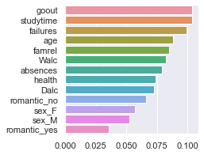

```python
feature_imp = pd.Series(clf.feature_importances_, index=X.columns).sort_values(ascending=False)
_= sns.barplot(x=feature_imp, y=feature_imp.index)
```

# Conclusions

## Regression

- Did not work so well for this dataset.. Oh well
- PCA made everything worse

**Linear Regression**:

> **MSE:** 21.89  
> **r^2 score:** 0.23

## Classification

- Grouped students into pass/fail based on final grade -> pass if G3 >= 10, fail if G3 < 10

**SVM**:

> **Accuracy:** 0.75  
> **F1_score:** 0.85

**Decision Tree**:

> **Accuracy score:** 0.61  
> **F1 score:** 0.71

**Random Forest Tree**:

> **Accuracy score:** 0.74  
> **F1_score:** 0.82